# slide_deck_template

## Bay Wheels (Ford Go Bike) Exploration and Visualization for yeay 2018

## Investigation Overview

> This exploration and visualization study mainly focuses on finding the bike usage and users categories and the avaerage duration for trips in the 12-month ride trips data in 2018 from January to December.We want to generate relationships between the trips duaration and the distance covered and the user types and the time intervals of trips .

## Dataset Overview

> Bay Wheels (previously known as Ford GoBike) is a public bike sharing system in the San Francisco Bay Area in California.The dataset used for this exploratory analysis consists of files containing monthly individual trip data from January 2018 to December 2018 in CSV format.These files were downloaded and gathered together to form one bog dataset containing some information like type of users , start and end time , start and end points and duration of the trips .

```python
# import all packages and set plots to be embedded inline
import numpy as np
import pandas as pd
import matplotlib.pyplot as plt
import seaborn as sb

%matplotlib inline

# suppress warnings from final output
import warnings
warnings.simplefilter("ignore")
```

After Gathering all the data we made the following tasks :

- Assess the data visually and programmatically
- Determine Quality issues and Tidiness issues
- Clean the data
- Add new columns to the data by making some calculations as distance , starting day , starting month and starting hour
- Save the new-cleaned data to a csv file

```python
# load in the dataset into a pandas dataframe
df=pd.read_csv('Master_Bikes2018_dataset_Cleaned.csv')
```

```python
# List of days in order
day_order = ['Mon', 'Tue', 'Wed', 'Thu', 'Fri', 'Sat', 'Sun']

# create ordered categorical variable
df['starting_WeekDay'] = pd.Categorical(df['starting_WeekDay'],
                                      categories= day_order, # use order list
                                      ordered = True)
```

> Note that the above cells have been set as "Skip"-type slides. That means that when the notebook is rendered as http slides, those cells won't show up.

## ( Distribution of trips duration in seconds )

> In this visualization , we are trying to plot the distribution of all trips duration in the data set  
> We found that most of the trips durations are up to 10000 seconds with some outliers that reached 80000 seconds

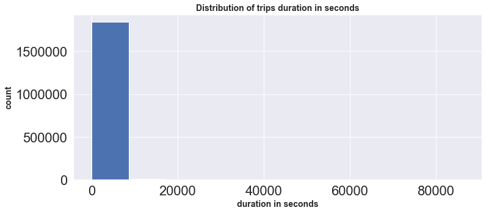

```python
plt.figure(figsize = [12, 5])
plt.hist(data = df, x = 'duration_sec')
plt.xlabel('duration in seconds',fontsize = 14, weight = "bold")
plt.ylabel('count',fontsize = 14, weight = "bold")
plt.title('Distribution of trips duration in seconds',fontsize = 14, weight = "bold");
```

we set a log scale on the x-axis to show the distribution of the duration , it is shown that most of the trips have duration from 500 to 1000 seconds .

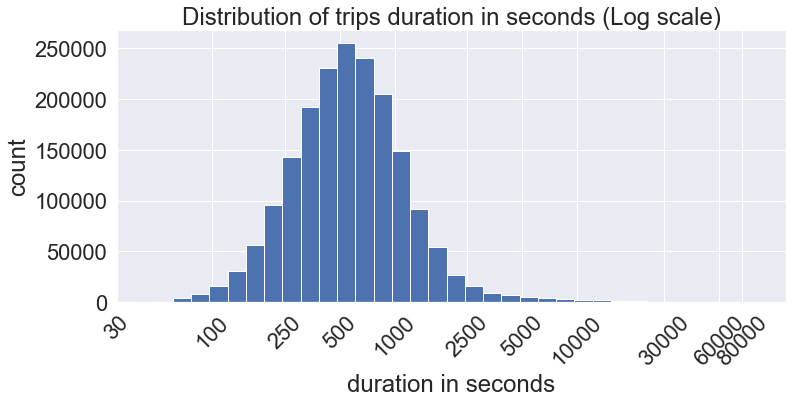

```python
plt.figure(figsize = [12, 5])
bin_edges = 10 ** np.arange(np.log10(df.duration_sec.min()), np.log10(df.duration_sec.max())+0.1, 0.1)
plt.hist(df.duration_sec, bins = bin_edges,edgecolor="white")
plt.xscale('log')
tick_locs = [30, 100,250,500, 1000,2500, 5000, 10000,30000 , 60000,80000]
plt.xlabel('duration in seconds')
plt.ylabel('count')
plt.xticks(tick_locs, tick_locs)
plt.xticks(rotation = 45)
plt.title('Distribution of trips duration in seconds (Log scale)');
```

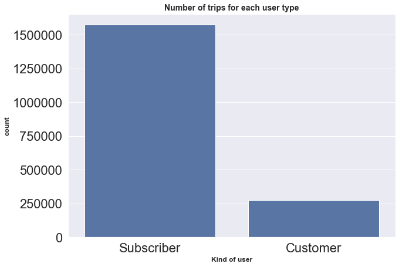

```python
plt.figure(figsize = [10, 7])
base_color = sb.color_palette()[0]
sb.countplot(data = df, x = 'user_type', color = base_color)
plt.title('Number of trips for each user type',fontsize = 14, weight = "bold")
plt.xlabel('Kind of user',fontsize = 12, weight = "bold")
plt.ylabel('count',fontsize = 12, weight = "bold");
```

## (Percentage of bike share for all trip)

[figure not shown]

```python
labels = ['Yes','No']
sizes = df.bike_share_for_all_trip.value_counts()
textprops = {"fontsize":15}

fig2, ax2 = plt.subplots()
ax2.pie(sizes, labels=labels, autopct='%1.1f%%',
        shadow=True, startangle=90 ,textprops =textprops)
ax2.axis('equal')  # Equal aspect ratio ensures that pie is drawn as a circle.
plt.title('Percentage of Bike share for all trips')
fig2.set_size_inches(8,6)
plt.show();
```

## (The relation betwen type of customer and starting week day)

> We are drawing thus relation as a heatmap , to show the denisty of trips for different user types with respect to the week days , it is noticed that subscriber users tend to have more trips on week days because they use the bikes for work routes purposes , while the customer users tend to have more trips on week ends because they use the bike more for fun purposes

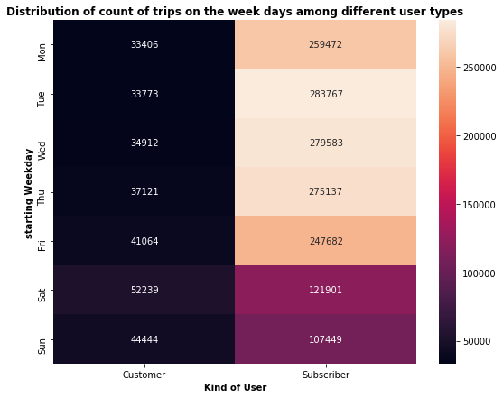

```python
ct_counts = df.groupby(['user_type', 'starting_WeekDay']).size()
ct_counts=ct_counts.reset_index(name='count')
ct_counts=ct_counts.pivot(index = 'starting_WeekDay', columns = 'user_type', values = 'count')
plt.figure(figsize = [9, 7])
sb.heatmap(ct_counts, annot = True, fmt = 'd')
plt.title('Distribution of count of trips on the week days among different user types',fontsize = 12, weight = "bold")
plt.xlabel('Kind of User',fontsize = 10, weight = "bold")
plt.ylabel('starting Weekday',fontsize = 10, weight = "bold");
```

## (The relation betwen type of customer and starting month of trip)

> From the clunstered bar chart , we notice that the subscriber trips are always more than customer trips and the biggest difference is found on October month , while the smallest difference is on January month

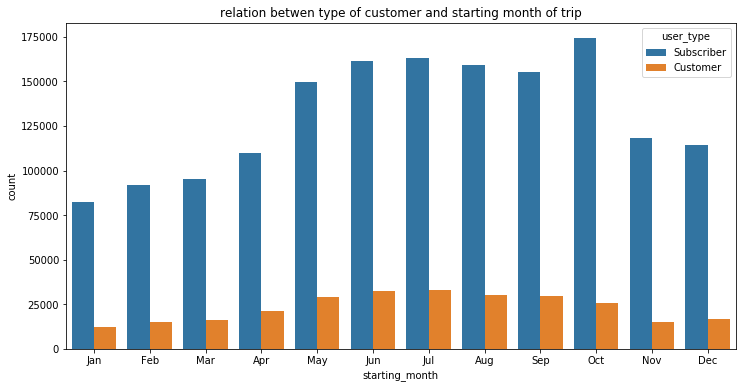

```python
plt.figure(figsize = [12, 6])
sb.countplot(data=df, x='starting_month', hue='user_type');
plt.title('relation betwen type of customer and starting month of trip');
```

## (The relation betwen the trip Distance and Duration with respect to the user type)

> As we see in the scatter plot , subscriber users tend to have shorter trips with less duration than the customer users , Also the relation between the distance and the durations is somehow directly proportional , but it is not very obvious from the plot due to large number of trips whose distance equals to zero , which indicates that some trips are rounded trips or two way trips

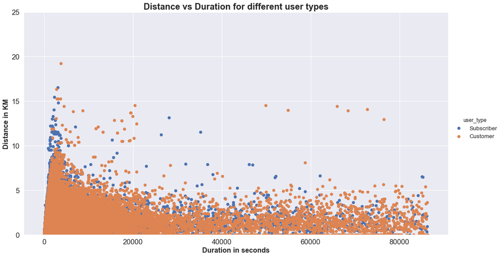

```python
g = sb.FacetGrid(data = df, hue = 'user_type' ,height = 8.27,aspect = 14.70/8.27)
g.map(plt.scatter, 'duration_sec', 'Distance')
sb.set(font_scale=1.2)
plt.ylim(0,25)
plt.title('Distance vs Duration for different user types',fontsize = 20, weight = "bold")
plt.xlabel('Duration in seconds',fontsize = 16, weight = "bold")
plt.ylabel('Distance in KM',fontsize = 16, weight = "bold")
g.add_legend();
```

## (Count of trips in each day of week with respect to the user type and bike share for all trips)

> From facetet grid , it is noticed that the highest count of trips in all days of the week (specially week days) is for the subscriber user with no bikes shared , followed by the customer user with no bike shared also , and then for the user subscriber with bikes shared for all trips , it is noticed that there is no trips for customer user with bikes shared all over the trips at all.

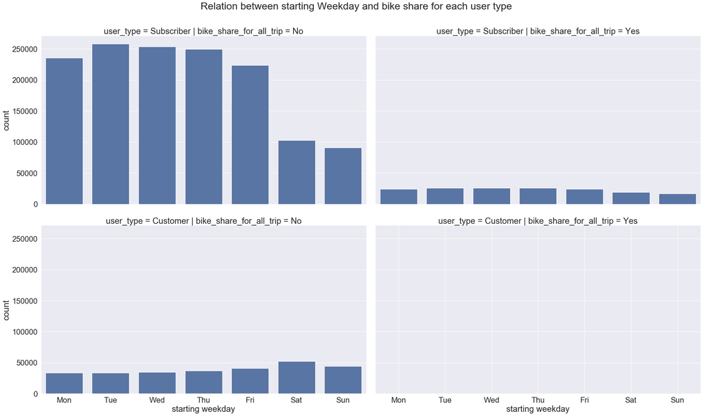

```python
g = sb.FacetGrid(data = df, col = 'bike_share_for_all_trip', size = 8  , row ='user_type' , height = 8/2,  aspect = (14/2)/(8/2))
sb.set(font_scale=2)
g.map(sb.countplot, 'starting_WeekDay' )
g.set_axis_labels(x_var="starting weekday", y_var="count")
plt.suptitle("Relation between starting Weekday and bike share for each user type", y = 1.04);
```

## Summary

> Once you're ready to finish your presentation, check your output by using nbconvert to export the notebook and set up a server for the slides. From the terminal or command line, use the following expression:

> > `jupyter nbconvert <file_name>.ipynb --to slides --post serve --template output_toggle`

> This should open a tab in your web browser where you can scroll through your presentation. Sub-slides can be accessed by pressing 'down' when viewing its parent slide. Make sure you remove all of the quote-formatted guide notes like this one before you finish your presentation!